# Classification

Dr. Liu Qizhang

1 November 2016

In previous lesson, you learned how to predict a categorical outcome using logistic regression. The process of predicting a categorical outcome from a set of predictors is called *Classification*, which is part of *pattern recognition*. Other than logistic regression, decision trees, random forests, support vector machines, and neural networks are some common methods used in classification. We will mainly discuss Naive Bayes, decision trees and random forests in this lesson.

# Naive Bayes Classification

Naive Bayes is a simplified version of Bayes’ Theorem by assuming all predictors are independent from each other. For an explanation of Naive Bayes Classification, please refer to http://stackoverflow.com/questions/10059594/a-simple-explanation-of-naive-bayes-classification.

I am going to use Lasagna Trier data to illustrate how to use it.

```r
triers <- read.csv("Lasagna Triers.csv")
triers$Person <- NULL
set.seed(123)
sample <- sample(c(TRUE,FALSE),nrow(triers),prob = c(0.75,0.25),replace = TRUE)

triers.train <- triers[sample, ]
triers.test <- triers[!sample, ]
```

Assume that we are going to use three predictors: Age, PayType, and Nbhd to predict whether a customer will be trier of the product. Then the probability of a customer with profle age 30, living in the west and working as part timer to be a trier will be calculated using the formula below:

p(Yes|Age=30,PayType=“Hourly”,Nbhd=“West”) =P(Age=30|Yes)P(PayType=“Hourly”|Yes)P(Nbhd=“West”|Yes)P(Yes) / [P(Age=30|Yes)P(PayType=“Hourly”|Yes)P(Nbhd=“West”|Yes)P(Yes) + P(Age=30|No)P(PayType=“Hourly”|No)P(Nbhd=“West”|No)P(No)]

It is quite easy to calculate P(Yes) and P(No).

```r
p.yes <- nrow(triers.train[triers.train$HaveTried=="Yes",])/nrow(triers.train)
p.no <- nrow(triers.train[triers.train$HaveTried=="No",])/nrow(triers.train)
p.yes
```

```
## [1] 0.5990712
```

```r
p.no
```

```
## [1] 0.4009288
```

For categorical predictor, it is also quite easy to calcualte the conditional probabilities. For example:

```r
p.West.Given.Yes <- nrow(triers.train[triers.train$HaveTried=="Yes"&triers.train$Nbhd=="West",])/nrow(triers.train[triers.train$HaveTried=="Yes",])
p.West.Given.Yes
```

```
## [1] 0.5994832
```

However, it will be a bit difficult for numerical predictors. There are two ways to handle numerical predictors. One way is to break the numerical values into categories according to some predefined thresholds, and then use the resulted categories as categorical predictor to calculate the posterior probability. For example, we may classify those with age below 30 as young and those above as senior. The problem with this approach is that the accuracy of the prediction depends very much on how the numercial values are classified.

Another approach is to use the probability distribution of the numerical predictor under different scenarios. Let’s take a look at the probability distributions of Age for the case of triers and nontriers respectively.

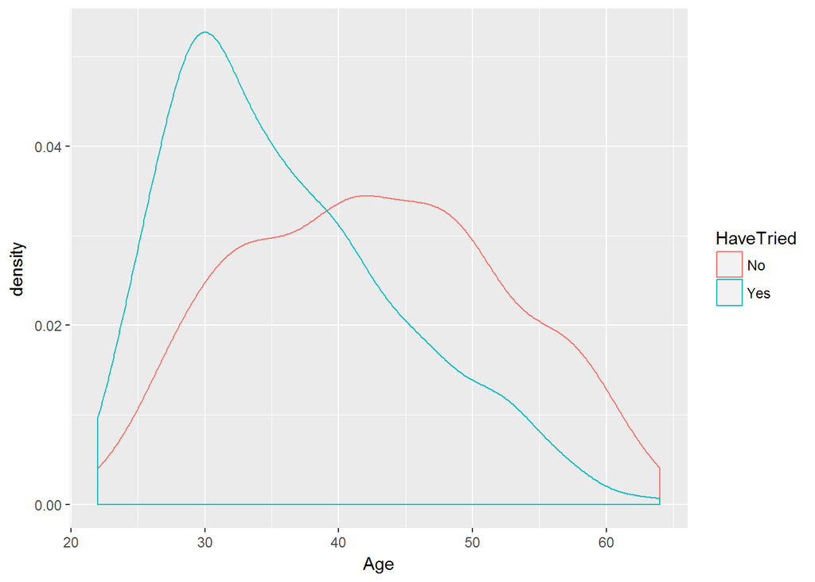

```r
library(ggplot2)
ggplot(triers,aes(x=Age,color=HaveTried)) + geom_density()
```

```r
shapiro.test(triers[triers$HaveTried=="Yes",]$Age)
```

```
##
##  Shapiro-Wilk normality test
##
## data:  triers[triers$HaveTried == "Yes", ]$Age
## W = 0.94679, p-value = 2.431e-12
```

```r
shapiro.test(triers[triers$HaveTried=="No",]$Age)
```

```
##
##  Shapiro-Wilk normality test
##
## data:  triers[triers$HaveTried == "No", ]$Age
## W = 0.98155, p-value = 0.0001412
```

```r
#Find the mean and standard deviation of ages for triers
mean.triers <- mean(triers.train[triers.train$HaveTried=="Yes",]$Age)
sd.triers <- sd(triers.train[triers.train$HaveTried=="Yes",]$Age)

#Find the mean and standard deviation of ages for nontriers
mean.nontriers <- mean(triers.train[triers.train$HaveTried=="No",]$Age)
sd.nontriers <- sd(triers.train[triers.train$HaveTried=="No",]$Age)

#Example: find the conditional probability of p(Age=30 | Yes)
dnorm(30,mean.triers,sd.triers)
```

```
## [1] 0.03618302
```

Based on the method of calculating prior probability and conditional probability, it is not difficult to write a procedure to calculate posterior probability using the Naive Bayes formula. I will leave this for you to try yourself.

```r
require(e1071)
#Build model using training set
m <- naiveBayes(HaveTried ~ ., data = triers.train)

#use the model to predict outcomes for test set
a<-table(predict(m, triers.train), triers.train$HaveTried)
accuracy <- (a[1,1]+a[2,2])/sum(a)
accuracy
```

```
## [1] 0.8080495
```

# Decision Trees

We are going to use German Credit data obtained from the UCI (University of California at Irwin) Machine Learning Repository (Asuncion and Newman, 2007). The data set, which contains attributes and outcomes on 1000 loan applications, was provided in 1994 by Professor Dr. Hans Hofmann of the Institut fuer Statistik und Oekonometrie at the University of Hamburg. The description of the data set is given in germancreditDescription.doc.

```r
credit <- read.csv("germancredit.csv")
summary(credit)
```

```
##     Default    checkingstatus1    duration    history      purpose
##  Min.   :0.0   A11:274         Min.   : 4.0   A30: 40   A43    :280
##  1st Qu.:0.0   A12:269         1st Qu.:12.0   A31: 49   A40    :234
##  Median :0.0   A13: 63         Median :18.0   A32:530   A42    :181
##  Mean   :0.3   A14:394         Mean   :20.9   A33: 88   A41    :103
##  3rd Qu.:1.0                   3rd Qu.:24.0   A34:293   A49    : 97
##  Max.   :1.0                   Max.   :72.0             A46    : 50
##                                                         (Other): 55
##      amount      savings   employ     installment    status     others
##  Min.   :  250   A61:603   A71: 62   Min.   :1.000   A91: 50   A101:907
##  1st Qu.: 1366   A62:103   A72:172   1st Qu.:2.000   A92:310   A102: 41
##  Median : 2320   A63: 63   A73:339   Median :3.000   A93:548   A103: 52
##  Mean   : 3271   A64: 48   A74:174   Mean   :2.973   A94: 92
##  3rd Qu.: 3972   A65:183   A75:253   3rd Qu.:4.000
##  Max.   :18424                       Max.   :4.000
##
##    residence     property        age        otherplans housing
##  Min.   :1.000   A121:282   Min.   :19.00   A141:139   A151:179
##  1st Qu.:2.000   A122:232   1st Qu.:27.00   A142: 47   A152:713
##  Median :3.000   A123:332   Median :33.00   A143:814   A153:108
##  Mean   :2.845   A124:154   Mean   :35.55
##  3rd Qu.:4.000              3rd Qu.:42.00
##  Max.   :4.000              Max.   :75.00
##
##      cards         job          liable        tele     foreign
##  Min.   :1.000   A171: 22   Min.   :1.000   A191:596   A201:963
##  1st Qu.:1.000   A172:200   1st Qu.:1.000   A192:404   A202: 37
##  Median :1.000   A173:630   Median :1.000
##  Mean   :1.407   A174:148   Mean   :1.155
##  3rd Qu.:2.000              3rd Qu.:1.000
##  Max.   :4.000              Max.   :2.000
##
```

We need to re-format the data for our analysis.

```r
#Convert "Default" field as factor
credit$Default <- factor(credit$Default)

#Re-level some variables
credit$history = factor(credit$history, levels=c("A30","A31","A32","A33","A34"))
levels(credit$history) = c("good","good","poor","poor","terrible")

credit$foreign <- factor(credit$foreign, levels=c("A201","A202"),labels=c("foreign","german"))

credit$purpose <- factor(credit$purpose, levels=c("A40","A41","A42","A43","A44","A45","A46","A47","A48","A49","A410"))
levels(credit$purpose) <- c("newcar","usedcar",rep("goods/repair",4), "edu",NA, "edu","biz","biz")

#Introduce a new variable to indicate if the applicant is renting a house
credit$rent <- factor(credit$housing=="A151")
```

Decision tree is a technique that separate observations into subgroups by creating splits on predictors. These split create logical rules that are transparent and easily understandable. The resulting subgroups should be more homogenous in terms of the outcome variable, thereby creating useful prediction or classification rules. We will look into two types of decision trees: classical trees and conditional inference trees.

## Classical decision trees

The following steps illustrate the procedure of spliting observations on predictors:

1. Choose the predictor variable that best splits the data into two groups suc that the purity (homogeneity) of the outcome in these two groups is maximized. If the predictor is continuous, choose a cut-point that maximizes purity for the two groups created. If the predictor variable is categorical, combine the categories to obtain two groups with maximum purity.
2. Separate the data into these two groups, and continue the process for each subgroup.
3. Repeat step 1 and 2 until a subgroup contains fewer tha a minimum number of observations or no splits decrease the impurity beyond a specific threshold. The subgroups in the final set are called *terminal nodes*. Each terminal node is classified as one category of the outcome or the other based on the most frequent value of the outcome for the sample in that node.
4. To classify a case, run it down the tree to a terminal node, and assign it the modal outcome value asigned in step 3.

### Splitting - explanaton of step 1

Now let’s use German Credit data to demonstrate how a data set is split and how purity is measured.

```r
#First understand the distribution of default and non-default cases
table(credit$Default)
```

```
##
##   0   1
## 700 300
```

```r
#Next, see the distribution by "foreign"
df.foreign <- as.data.frame.matrix(table(credit$foreign, credit$Default))
df.foreign$default.rate <- df.foreign[,2]/(df.foreign[,1]+df.foreign[,2])
df.foreign
```

```
##           0   1 default.rate
## foreign 667 296    0.3073728
## german   33   4    0.1081081
```

```r
#See the distribution by "history"
df.history <- as.data.frame.matrix(table(credit$history, credit$Default))
df.history$default.rate <- df.history[,2]/(df.history[,1]+df.history[,2])
df.history
```

```
##            0   1 default.rate
## good      36  53    0.5955056
## poor     421 197    0.3187702
## terrible 243  50    0.1706485
```

Use different categorical predictor will result in different purity. There are also different ways to measure and compare overall purity in different decision tree algorithms. For example, some will compare by the higher purity of the two groups, some will compare by average purity of the two groups, and some will compare by weighted average of the two groups. We may split by “history” and classify those with “good” history as one group and those with “poor” and “terrible” as another group.

### Decision Tree Function

The normal decision tree procedure as described above tends to produce a tree with too many terminal nodes and thus suffers from overfitting. You may have to prune the tree by choosing the tree with the lowest 10-fold cross-validated prediction error.

Let’s apply the decision tree classification method on German credit data again. We start with a general purpose classification, which is to minimize the misclassification error.

```r
library(rpart)
set.seed(1234)
sample <- sample(c(TRUE,FALSE),nrow(credit),prob = c(0.8,0.2),replace = TRUE)
credit.train <- credit[sample, ]
credit.test <- credit[!sample, ]

dtree <- rpart(Default ~ ., data=credit.train, method="class", parms=list(split="information"))
summary(dtree)
```

```
## Call:
## rpart(formula = Default ~ ., data = credit.train, method = "class",
##     parms = list(split = "information"))
##   n= 792
##
##           CP nsplit rel error    xerror       xstd
## 1 0.04424779      0 1.0000000 1.0000000 0.05623302
## 2 0.03539823      3 0.8407080 0.9203540 0.05479830
## 3 0.01991150      4 0.8053097 0.9115044 0.05462751
## 4 0.01327434      6 0.7654867 0.8982301 0.05436691
## 5 0.01032448     10 0.7123894 0.8893805 0.05419020
## 6 0.01000000     13 0.6814159 0.8893805 0.05419020
##
## Variable importance
## checkingstatus1        duration         savings          amount
##              33              16              11               8
##         history         purpose          employ       residence
##               8               6               4               4
##        property             age         housing            tele
##               2               2               2               2
##             job            rent           cards
##               1               1               1
##
## Node number 1: 792 observations,    complexity param=0.04424779
##   predicted class=0  expected loss=0.2853535  P(node) =1
##     class counts:   566   226
##    probabilities: 0.715 0.285
##   left son=2 (361 obs) right son=3 (431 obs)
##   Primary splits:
##       checkingstatus1 splits as  RRLL,        improve=44.59748, (0 missing)
##       savings         splits as  RRLLL,       improve=17.59279, (0 missing)
##       amount          < 3913.5  to the left,  improve=15.24507, (0 missing)
##       history         splits as  RRL,         improve=15.02310, (0 missing)
##       duration        < 15.5    to the left,  improve=14.73575, (0 missing)
##   Surrogate splits:
##       savings  splits as  RRLLL,       agree=0.614, adj=0.152, (0 split)
##       history  splits as  RRL,         agree=0.586, adj=0.091, (0 split)
##       employ   splits as  RRRRL,       agree=0.563, adj=0.042, (0 split)
##       duration < 5.5     to the left,  agree=0.553, adj=0.019, (0 split)
##       purpose  splits as  RLRRR,       agree=0.553, adj=0.019, (0 split)
```

[output cut: 235 more lines]

```
##
## Node number 491: 7 observations
##   predicted class=1  expected loss=0  P(node) =0.008838384
##     class counts:     0     7
##    probabilities: 0.000 1.000
##
## Node number 980: 18 observations
##   predicted class=0  expected loss=0.3333333  P(node) =0.02272727
##     class counts:    12     6
##    probabilities: 0.667 0.333
##
## Node number 981: 24 observations
##   predicted class=1  expected loss=0.3333333  P(node) =0.03030303
##     class counts:     8    16
##    probabilities: 0.333 0.667
```

```r
print(dtree)
```

```
## n= 792
##
## node), split, n, loss, yval, (yprob)
##       * denotes terminal node
##
##   1) root 792 226 0 (0.7146465 0.2853535)
##     2) checkingstatus1=A13,A14 361  45 0 (0.8753463 0.1246537) *
##     3) checkingstatus1=A11,A12 431 181 0 (0.5800464 0.4199536)
##       6) duration< 22.5 249  80 0 (0.6787149 0.3212851)
##        12) history=poor,terrible 229  66 0 (0.7117904 0.2882096)
##          24) duration< 11.5 69  11 0 (0.8405797 0.1594203) *
##          25) duration>=11.5 160  55 0 (0.6562500 0.3437500)
##            50) amount>=979.5 135  41 0 (0.6962963 0.3037037) *
##            51) amount< 979.5 25  11 1 (0.4400000 0.5600000)
##             102) residence>=3.5 10   3 0 (0.7000000 0.3000000) *
##             103) residence< 3.5 15   4 1 (0.2666667 0.7333333) *
##        13) history=good 20   6 1 (0.3000000 0.7000000) *
##       7) duration>=22.5 182  81 1 (0.4450549 0.5549451)
##        14) savings=A64,A65 28   6 0 (0.7857143 0.2142857) *
##        15) savings=A61,A62,A63 154  59 1 (0.3831169 0.6168831)
##          30) duration< 47.5 122  54 1 (0.4426230 0.5573770)
##            60) purpose=usedcar 19   5 0 (0.7368421 0.2631579) *
##            61) purpose=newcar,goods/repair,edu,biz 103  40 1 (0.3883495 0.6116505)
##             122) tele=A191 59  28 1 (0.4745763 0.5254237)
##               244) residence< 1.5 10   2 0 (0.8000000 0.2000000) *
##               245) residence>=1.5 49  20 1 (0.4081633 0.5918367)
##                 490) employ=A71,A73,A74,A75 42  20 1 (0.4761905 0.5238095)
##                   980) age>=31.5 18   6 0 (0.6666667 0.3333333) *
##                   981) age< 31.5 24   8 1 (0.3333333 0.6666667) *
##                 491) employ=A72 7   0 1 (0.0000000 1.0000000) *
##             123) tele=A192 44  12 1 (0.2727273 0.7272727) *
##          31) duration>=47.5 32   5 1 (0.1562500 0.8437500) *
```

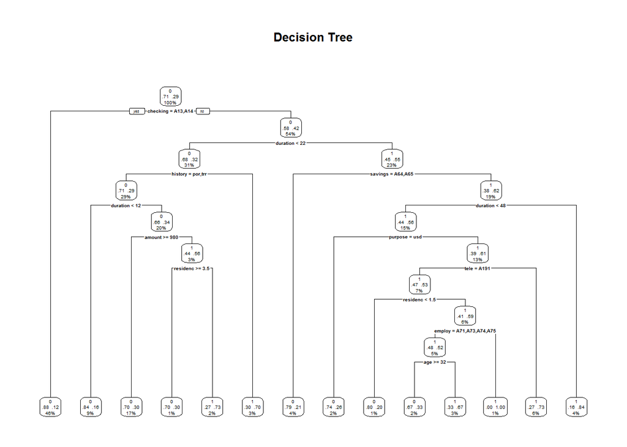

```r
library(rpart.plot)
prp(dtree, type=2, extra=104, fallen.leaves = TRUE, main="Decision Tree")
```

*summary*, *print* and *prp* are the functions to view the details of the classification. As you can see, there seems to have too many terminal nodes. We can examine the *cptable* component of the list returned by *rpart()* and determine the best size of the tree.

```r
dtree$cptable
```

```
##           CP nsplit rel error    xerror       xstd
## 1 0.04424779      0 1.0000000 1.0000000 0.05623302
## 2 0.03539823      3 0.8407080 0.9203540 0.05479830
## 3 0.01991150      4 0.8053097 0.9115044 0.05462751
## 4 0.01327434      6 0.7654867 0.8982301 0.05436691
## 5 0.01032448     10 0.7123894 0.8893805 0.05419020
## 6 0.01000000     13 0.6814159 0.8893805 0.05419020
```

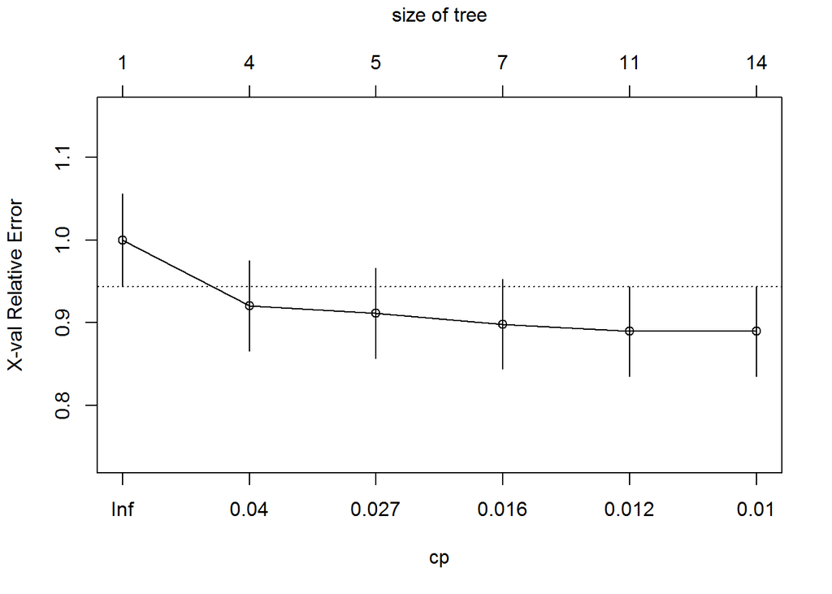

```r
plotcp(dtree)
```

A tree with *n* splits has *n+1* terminal nodes. The *rel error* column contains the error rate for a tree of a given size in the training smaple. The cross validated error *xerror* is based on 10-fold cross validation. The *xstd* column contains the standard error of the cross-validation error. The complexity parameter *cp* is used to penalise large trees. Tree size is defined by the number of branch splits *nsplit*. The *plotcp()* function plots the cross-validated error against the complexity parameter. A good choice for the final tree size is the smallest tree whose cross-validated error is within one standard error of the minimum cross-validated error value.

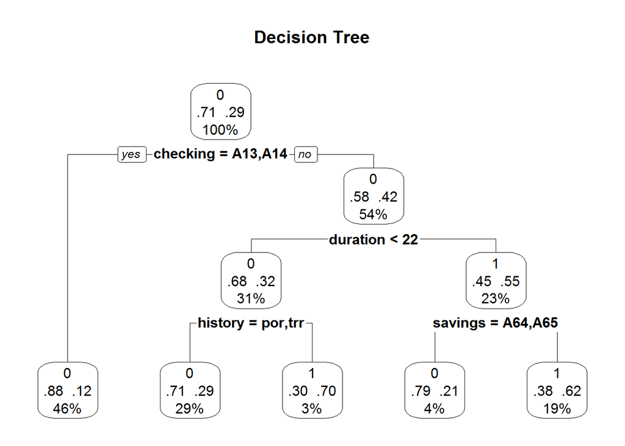

```r
dtree.pruned <- prune(dtree, cp=0.023)
prp(dtree.pruned, type=2, extra=104, fallen.leaves = TRUE, main="Decision Tree")
```

```r
dtree.pred <- predict(dtree.pruned, credit.test, type="class")
accuracy <- table(credit.test$Default, dtree.pred,dnn=c("Actual","Predicted"))
accuracy
```

```
##       Predicted
## Actual   0   1
##      0 118  16
##      1  40  34
```

You can adjust the prune criteria by lowering the *cp* value. What is the effect? How to interpret it?

One thing you may have observed is that the model above did not take the cost of mis-classification into consideration. You can use *loss=* to specify the cost matrix.

```r
set.seed(1234)
dtree <- rpart(Default ~ ., data=credit.train, method="class", parms=list(split="information",loss=matrix(c(0,1,5,0), byrow=TRUE, nrow=2)))
dtree$cptable
```

```
##           CP nsplit rel error   xerror      xstd
## 1 0.16077739      0 1.0000000 5.000000 0.1122673
## 2 0.07773852      1 0.8392226 2.411661 0.1157540
## 3 0.02650177      2 0.7614841 2.713781 0.1192690
## 4 0.01766784      4 0.7084806 2.671378 0.1188542
## 5 0.01590106      8 0.6378092 2.745583 0.1196318
## 6 0.01413428      9 0.6219081 2.833922 0.1202906
## 7 0.01236749     13 0.5653710 2.613074 0.1182173
## 8 0.01000000     14 0.5530035 2.544170 0.1169528
```

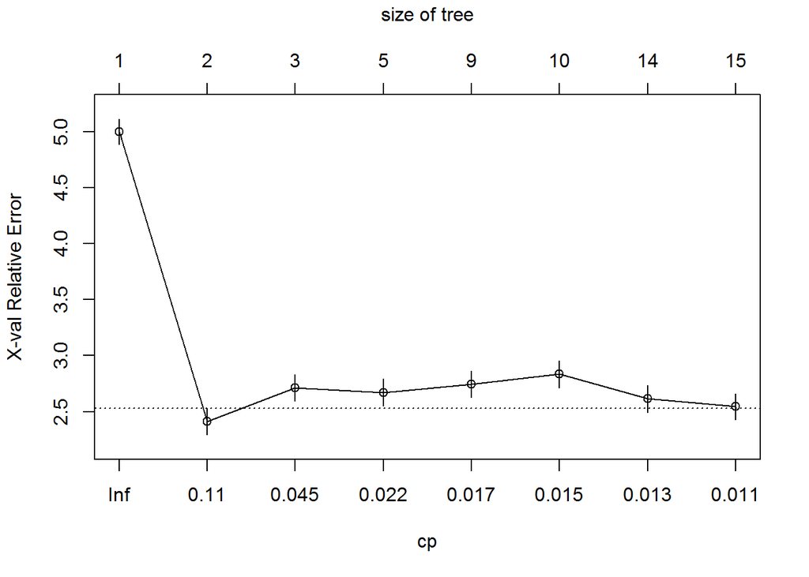

```r
plotcp(dtree)
```

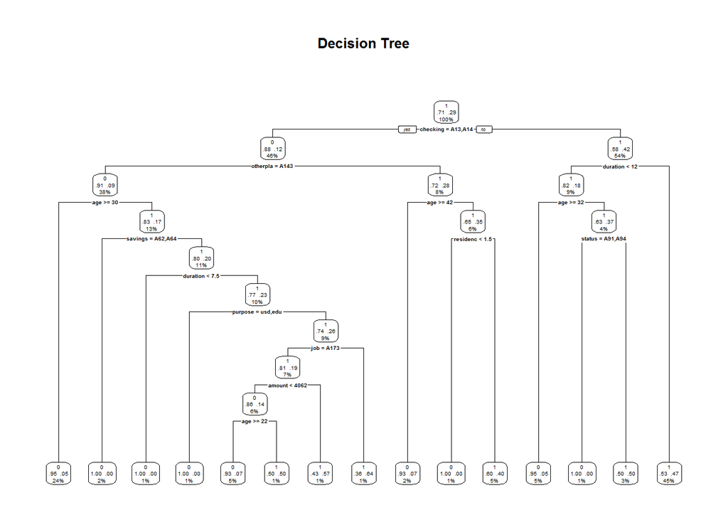

```r
dtree.pruned <- prune(dtree, cp=0.011)
prp(dtree.pruned, type=2, extra=104, fallen.leaves = TRUE, main="Decision Tree")
```

```r
dtree.pred <- predict(dtree.pruned, credit.test, type="class")
accuracy <- table(credit.test$Default, dtree.pred,dnn=c("Actual","Predicted"))
accuracy
```

```
##       Predicted
## Actual  0  1
##      0 76 58
##      1 14 60
```

You can see a much better result in terms of reduced number of mis-classifying default case as non-default case.

## Conditional Inference Trees

Cnoditional inference trees are similar to classical decision trees, but variables and splits are selected based on significance tests rather than purity/homogeneity measures.

```r
library(grid)
library(mvtnorm)
library(modeltools)
library(stats4)
library(strucchange)
library(zoo)
library(party)
```

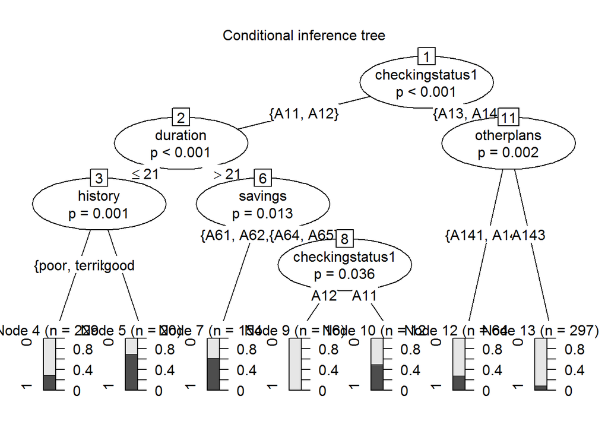

```r
fit.ctree <- ctree(Default ~ ., data=credit.train)
plot(fit.ctree, main="Conditional inference tree")
```

```r
ctree.pred <- predict(fit.ctree, credit.test, type="response")
accuracy <- table(credit.test$Default, ctree.pred,dnn=c("Actual","Predicted"))
accuracy
```

```
##       Predicted
## Actual   0   1
##      0 118  16
##      1  40  34
```

[figure not shown]

```r
fit.ctree <- ctree(Default ~ ., data=credit.train, weights = ifelse(credit.train$Default=="0",1,5))
plot(fit.ctree, main="Conditional inference tree")
```

```r
ctree.pred <- predict(fit.ctree, credit.test, type="response")
accuracy <- table(credit.test$Default, ctree.pred,dnn=c("Actual","Predicted"))
accuracy
```

```
##       Predicted
## Actual  0  1
##      0 89 45
##      1 20 54
```

# Random Forests

Random Forests is an ensemble learning method for classification, regression and other tasks, that operate by constructing a multitude of decision trees at training time and outputting the class that is the mode of the classes (classification) or mean prediction (regression) of the individual trees. Random decision forests correct for decision trees’ habit of overfitting to their training set.

The algorithm of random forests works like the following:

- Grow a large number of decision trees by sampling N cases with replacement from the training set.
- Sample m<N variables at each node. These variables are considered candidates for splitting in that node. The value m is the same for each node.
- Grow each tree fully without pruning.
- Terminal nodes are assigned to a class based on the mode of cases in that node.
- Classify new cases by sending them down all the trees and taking a vote - majority rules.

The following codes shows how to run random forests on the credit data set.

```r
library(randomForest)
set.seed(1234)

fit.forest <- randomForest(Default ~., data=credit.train, na.action = na.roughfix,importance=TRUE, cutoff=c(.85,.15))
importance(fit.forest, type=2)
```

```
##                 MeanDecreaseGini
## checkingstatus1        31.891733
## duration               31.119579
## history                13.664901
## purpose                17.218829
## amount                 43.864843
## savings                18.153907
## employ                 18.580279
## installment            13.333153
## status                 12.692745
## others                  5.676905
## residence              12.915650
## property               15.653087
## age                    32.494163
## otherplans              8.831911
## housing                 7.834311
## cards                   7.986569
## job                    10.807087
## liable                  4.559765
## tele                    5.399966
## foreign                 1.140202
## rent                    3.495824
```

```r
forest.predict <- predict(fit.forest,credit.test)
accuracy <- table(credit.test$Default, forest.predict,dnn=c("Actual","Predicted"))
accuracy
```

```
##       Predicted
## Actual  0  1
##      0 48 86
##      1  7 67
```

The cutoff parameter in the above codes is the way to handle the asymmetric costs. If the costs are not asymmetric, then you may just exclude this parameter from the function.

# SVM

Support Vector Machines (*SVMs*) recently gains a lot of attention and becomes more and more popular due to the beautiful mathematics theory behind it. Please refer to my video for an introduction on it.